[output not shown]

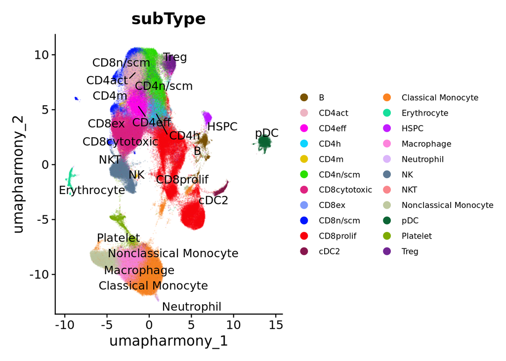

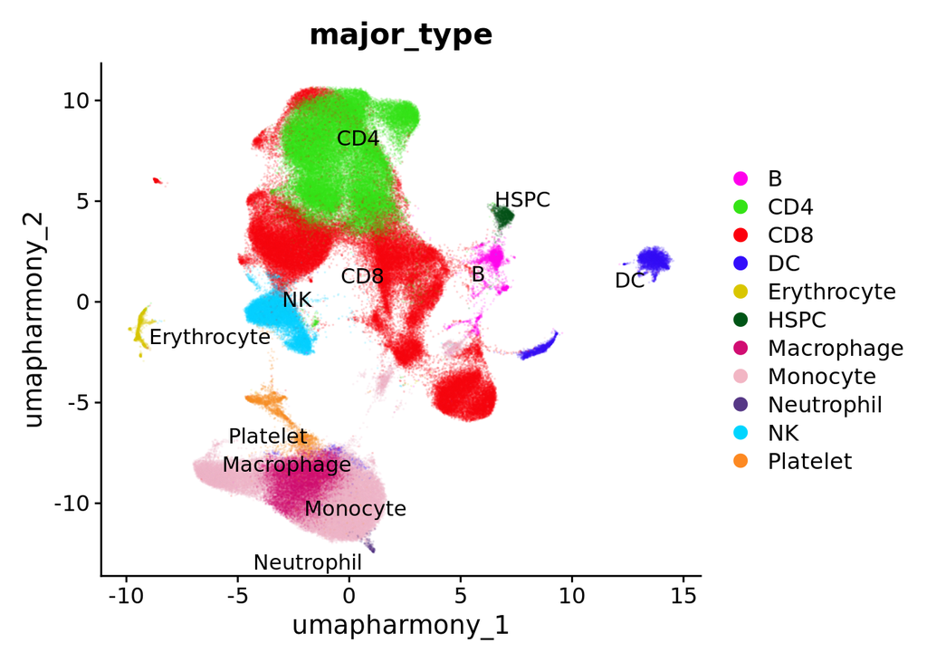

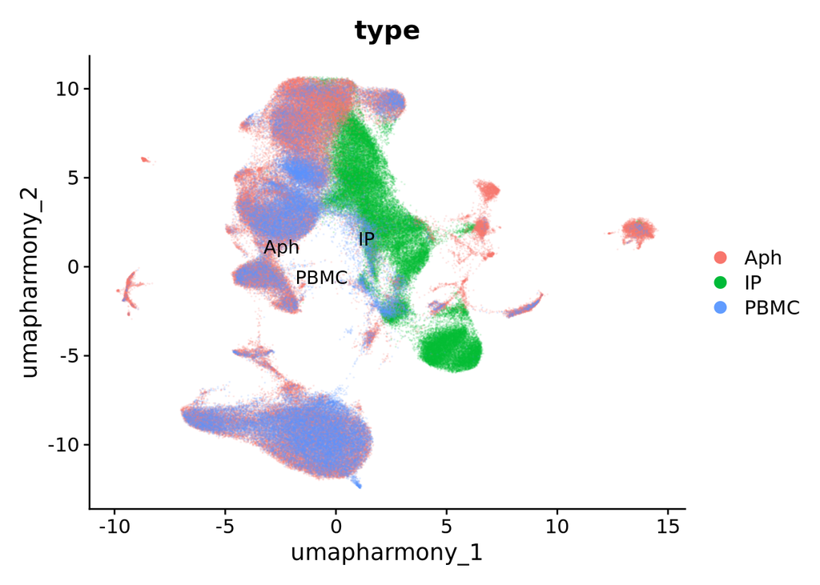

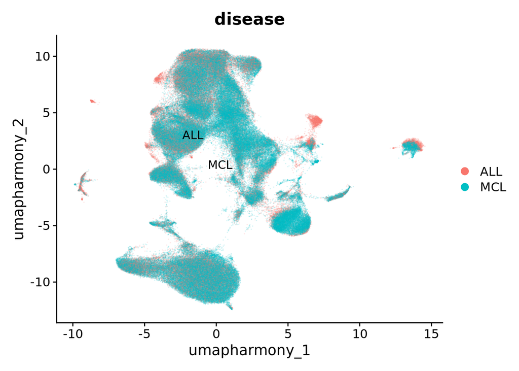

## QC reports

[QC_1](https://jeraldnoble.github.io/brexucel/docs/qc_tecartus.html)  
[QC_2](https://jeraldnoble.github.io/brexucel/docs/qc_tecartus_short.html)

## Single cell differential expression reports by disease

[DGE between ALL and MCL in Aph](https://jeraldnoble.github.io/brexucel/docs/dge_disease_aph.html)  
[DGE between ALL and MCL in IP](https://jeraldnoble.github.io/brexucel/docs/dge_disease_ip.html)  
[DGE between ALL and MCL in PBMC](https://jeraldnoble.github.io/brexucel/docs/dge_disease_pbmc.html)

## Single cell differential expression reports by response

[DGE between responders in Aph](https://jeraldnoble.github.io/brexucel/docs/dge_response_aph_metap.html)  
[DGE between responders in IP](https://jeraldnoble.github.io/brexucel/docs/dge_response_ip_metap.html)  
[DGE between responders in PBMC](https://jeraldnoble.github.io/brexucel/docs/dge_response_pbmc_metap.html)

## Gene signature expression differences between responders and diseases

[Gene signature comparisons in Aph](https://jeraldnoble.github.io/brexucel/docs/ssgsea_aph.html)  
[Gene signature comparisons in IP](https://jeraldnoble.github.io/brexucel/docs/ssgsea_ip.html)  
[Gene signature comparisons in PBMC](https://jeraldnoble.github.io/brexucel/docs/ssgsea_pbmc.html)

## Single cell differential expression reports by CRS >1

[DGE between CRS > 1 in Aph](https://jeraldnoble.github.io/brexucel/docs/dge_crs_aph_metap.html)  
[DGE between CRS > 1 in IP](https://jeraldnoble.github.io/brexucel/docs/dge_crs_ip_metap.html)  
[DGE between CRS > 1 in PBMC](https://jeraldnoble.github.io/brexucel/docs/dge_crs_pbmc_metap.html)

## Gene signature expression differences by CRS > 1

[Gene signature comparisons in Aph](https://jeraldnoble.github.io/brexucel/docs/ssgsea_aph_crs.html)  
[Gene signature comparisons in IP](https://jeraldnoble.github.io/brexucel/docs/ssgsea_ip_crs.html)  
[Gene signature comparisons in PBMC](https://jeraldnoble.github.io/brexucel/docs/ssgsea_pbmc_crs.html)

## Single cell differential expression reports by ICANS >2

[DGE between ICANS > 2 in Aph](https://jeraldnoble.github.io/brexucel/docs/dge_icans_aph_metap.html)  
[DGE between ICANS > 2 in IP](https://jeraldnoble.github.io/brexucel/docs/dge_icans_ip_metap.html)  
[DGE between ICANS > 2 in PBMC](https://jeraldnoble.github.io/brexucel/docs/dge_icans_pbmc_metap.html)

## Gene signature expression differences by ICANS > 2

[Gene signature comparisons in Aph](https://jeraldnoble.github.io/brexucel/docs/ssgsea_aph_icans.html)  
[Gene signature comparisons in IP](https://jeraldnoble.github.io/brexucel/docs/ssgsea_ip_icans.html)  
[Gene signature comparisons in PBMC](https://jeraldnoble.github.io/brexucel/docs/ssgsea_pbmc_icans.html)

## Single cell differential expression CAR+ vs CAR-

[DGE between CAR+ and CAR- in IP](https://jeraldnoble.github.io/brexucel/docs/dge_carPos_ip.html)  
[DGE between CAR+ and CAR- in PBMC](https://jeraldnoble.github.io/brexucel/docs/dge_carPos_pbmc.html)

## Cell type compositions between responders and disease

[Cell type composition differences between diseases and responders](https://jeraldnoble.github.io/brexucel/docs/cell_type_comps.html)

## % CAR+ cells between responders and correlates with %CAR+ cells in PBMC

[Percentage of CAR+ cells between responders in IP and PBMC](https://jeraldnoble.github.io/brexucel/docs/perc_car_pos_analysis.html)

## PBMC markers association with outcome, disease, CRS, and ICANS

[PBMC markers](https://jeraldnoble.github.io/brexucel/docs/blood_markers.html)

## Cell:cell interactions with cellchat

[Cell:cell interactions](https://jeraldnoble.github.io/brexucel/docs/cell_chat.html)